# individual2

Colin Willenborg

9/23/2020

```r
dat <- readxl::read_xls('./GSS.xls')
dat <- dat %>%
  rename(
    Year = 'Gss year for this respondent',
    Happiness = 'General happiness',
    Religion = 'Religion in which raised',
    Political.Party = 'Political party affiliation',
    Sex = 'Respondents sex',
    Degree = 'Rs highest degree',
    Year.School = 'Highest year of school completed',
    Children = 'Number of children',
    Marital.Status = 'Marital status',
    Self.Emp = 'R self-emp or works for somebody',
    ID = 'Respondent id number',
    Ballot = 'Ballot used for interview'
  )
dat$Children <- as.numeric(dat$Children)
dat$Year.School <- as.numeric(dat$Year.School)
```

## Question 1: Education vs Political Party

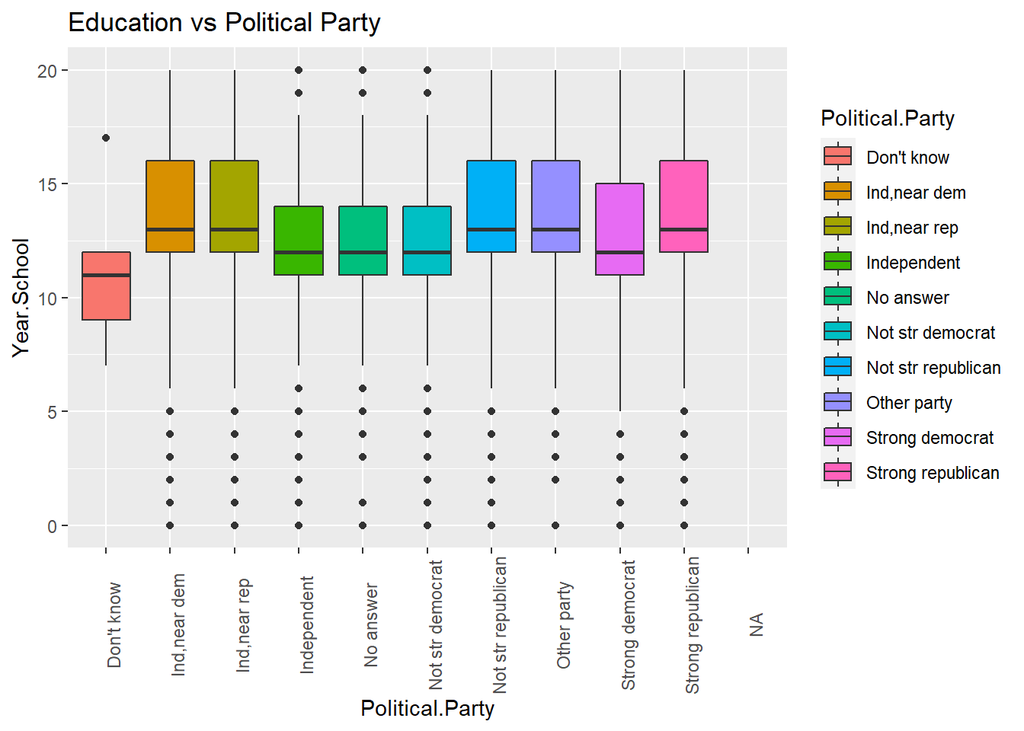

```r
education <- select(dat, Year.School, Political.Party)
p <- ggplot(education, aes(x=Political.Party, y=Year.School, fill=Political.Party)) + geom_boxplot() + ggtitle("Education vs Political Party")
p + theme(axis.text.x=element_text(angle=90))
```

The above graph splits the respondents into groups based on Political Party and then shows a boxplot representation for the individual parties. People who identify as independent near democrat/republican on average have higher education than normal independent. The not strong republican and strong republican have a greater average education than the counter parts of not strong democrat and strong democrat. It is also interesting to note that a respondent identifying with a political party has a higher average education level than respondents with no education which could mean that the less educated you are the less you participate in politics.

## Question 2: Dataframe for Education above the median in Political Parties

```r
education <- dat %>%
  select(Political.Party, Year.School) %>%
  drop_na %>%
  group_by(Political.Party) %>%
  mutate(Year.School = as.numeric(Year.School, na.rm=TRUE)) %>%
  filter( Year.School >= median(Year.School, na.rm=TRUE))
str(education)
```

```
## tibble [40,925 x 2] (S3: grouped_df/tbl_df/tbl/data.frame)
##  $ Political.Party: chr [1:40925] "Ind,near dem" "Independent" "Not str democrat" "Strong democrat" ...
##  $ Year.School    : num [1:40925] 16 12 17 12 14 13 16 12 12 13 ...
##  - attr(*, "groups")= tibble [10 x 2] (S3: tbl_df/tbl/data.frame)
##   ..$ Political.Party: chr [1:10] "Don't know" "Ind,near dem" "Ind,near rep" "Independent" ...
##   ..$ .rows          : list<int> [1:10]
##   .. ..$ : int [1:7] 1471 1479 1881 1972 2045 2201 35313
##   .. ..$ : int [1:3949] 1 5 6 7 13 15 26 34 43 53 ...
##   .. ..$ : int [1:2944] 12 14 19 37 68 84 87 89 90 105 ...
##   .. ..$ : int [1:7141] 2 17 18 24 27 31 36 39 45 71 ...
##   .. ..$ : int [1:271] 546 934 942 994 1220 1576 1599 1752 1868 1915 ...
##   .. ..$ : int [1:9935] 3 21 25 33 41 44 49 54 56 58 ...
##   .. ..$ : int [1:5188] 22 23 32 35 40 48 51 66 83 95 ...
##   .. ..$ : int [1:605] 38 42 47 96 149 169 201 215 276 284 ...
##   .. ..$ : int [1:7306] 4 8 9 10 11 20 28 29 30 46 ...
##   .. ..$ : int [1:3579] 16 50 52 80 82 101 103 148 163 171 ...
##   .. ..@ ptype: int(0)
##   ..- attr(*, ".drop")= logi TRUE
```

## Question 3: Happiness vs Marital Status

```r
marriedData <- dat %>% select(Happiness, Marital.Status) %>% drop_na
marriedData <- marriedData %>% filter(Marital.Status != 'No Answer' &
                                        Marital.Status != 'No answer' &
                                        Happiness != "Don't know" &
                                        Happiness != "No answer" &
                                        Happiness != 'Not applicable')
str(marriedData)
```

```
## tibble [60,034 x 2] (S3: tbl_df/tbl/data.frame)
##  $ Happiness     : chr [1:60034] "Not too happy" "Not too happy" "Pretty happy" "Not too happy" ...
##  $ Marital.Status: chr [1:60034] "Never married" "Married" "Married" "Married" ...
```

```r
marriedData <- marriedData %>% mutate(Marital.Status = factor(Marital.Status, levels = c('Never married', 'Divorced', 'Seperated', 'Widowed', 'Married'))) %>%
  arrange(Marital.Status)
summary(marriedData)
```

```
##   Happiness               Marital.Status
##  Length:60034       Never married:12741
##  Class :character   Divorced     : 7630
##  Mode  :character   Seperated    :    0
##                     Widowed      : 5815
##                     Married      :31773
##                     NA's         : 2075
```

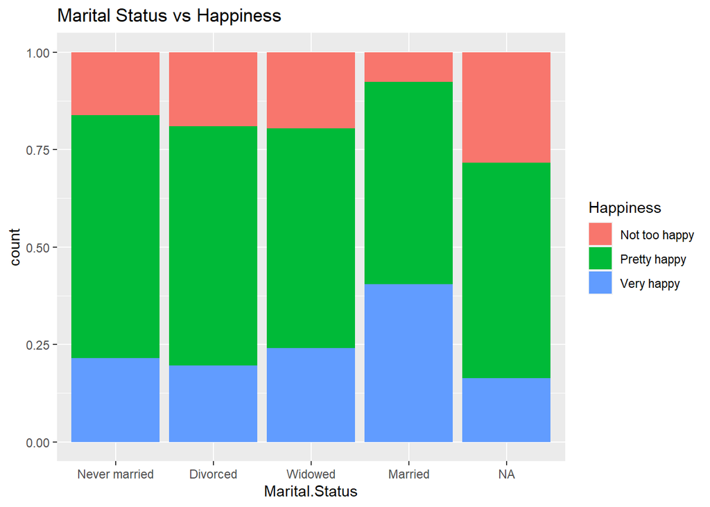

```r
ggplot(marriedData, aes(x=Marital.Status, fill=Happiness)) + geom_bar(position = 'fill') + ggtitle("Marital Status vs Happiness")
```

The graph shows that respondents that were married had a greater portion, by a significant margin, that wer very happy versus other groups.

## Question 4: Party Affiliation vs Happiness/Marital Status

```r
marriedData <- dat %>% select(Happiness, Political.Party, Marital.Status) %>% drop_na
marriedData <- marriedData %>% filter(Marital.Status != 'No Answer' &
                                        Marital.Status != 'No answer' &
                                        Happiness != "Don't know" &
                                        Happiness != "No answer" &
                                        Happiness != 'Not applicable' &
                                        Political.Party != "Don't know" &
                                        Political.Party != "No answer" &
                                        Political.Party != 'Not applicable')
str(marriedData)
```

```
## tibble [59,682 x 3] (S3: tbl_df/tbl/data.frame)
##  $ Happiness      : chr [1:59682] "Not too happy" "Not too happy" "Pretty happy" "Not too happy" ...
##  $ Political.Party: chr [1:59682] "Ind,near dem" "Not str democrat" "Independent" "Not str democrat" ...
##  $ Marital.Status : chr [1:59682] "Never married" "Married" "Married" "Married" ...
```

```r
marriedData <- marriedData %>% mutate(Marital.Status = factor(Marital.Status, levels = c('Never married', 'Divorced', 'Seperated', 'Widowed', 'Married'))) %>%
  arrange(Marital.Status)
summary(marriedData)
```

```
##   Happiness         Political.Party          Marital.Status
##  Length:59682       Length:59682       Never married:12668
##  Class :character   Class :character   Divorced     : 7579
##  Mode  :character   Mode  :character   Seperated    :    0
##                                        Widowed      : 5770
##                                        Married      :31604
##                                        NA's         : 2061
```

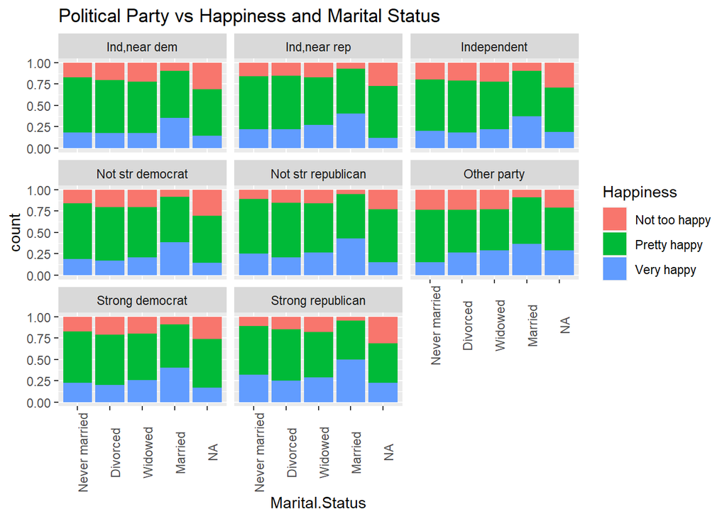

```r
ggplot(marriedData, aes(x=Marital.Status, fill=Happiness)) + geom_bar(position = 'fill') + facet_wrap(~marriedData$Political.Party) + theme(axis.text.x=element_text(angle=90))+ ggtitle("Political Party vs Happiness and Marital Status")
```

The trends for political party and marriage are fairly consistant throughout the graphs so it doesn’t show any evidence that says political party has anything to do with marriage.

## Question 5: Marital Status vs Education

```r
marriedData <- dat %>% select(Year.School, Marital.Status) %>% drop_na
marriedData <- marriedData %>% filter(Marital.Status != 'No Answer' &
                                        Marital.Status != 'No answer') %>%
  group_by(Marital.Status)
marriedData %>%
  summarise(average = mean(Year.School))
```

```
## # A tibble: 5 x 2
##   Marital.Status average
##   <chr>            <dbl>
## 1 Divorced          13.1
## 2 Married           13.0
## 3 Never married     13.4
## 4 Separated         11.9
## 5 Widowed           11.2
```

```r
marriedData <- marriedData %>% mutate(Marital.Status = factor(Marital.Status, levels = c('Never married', 'Divorced', 'Seperated', 'Widowed', 'Married'))) %>%
  arrange(Marital.Status)
summary(marriedData)
```

```
##   Year.School          Marital.Status
##  Min.   : 0.00   Never married:13801
##  1st Qu.:12.00   Divorced     : 8363
##  Median :12.00   Seperated    :    0
##  Mean   :12.87   Widowed      : 6164
##  3rd Qu.:15.00   Married      :34053
##  Max.   :20.00   NA's         : 2233
```

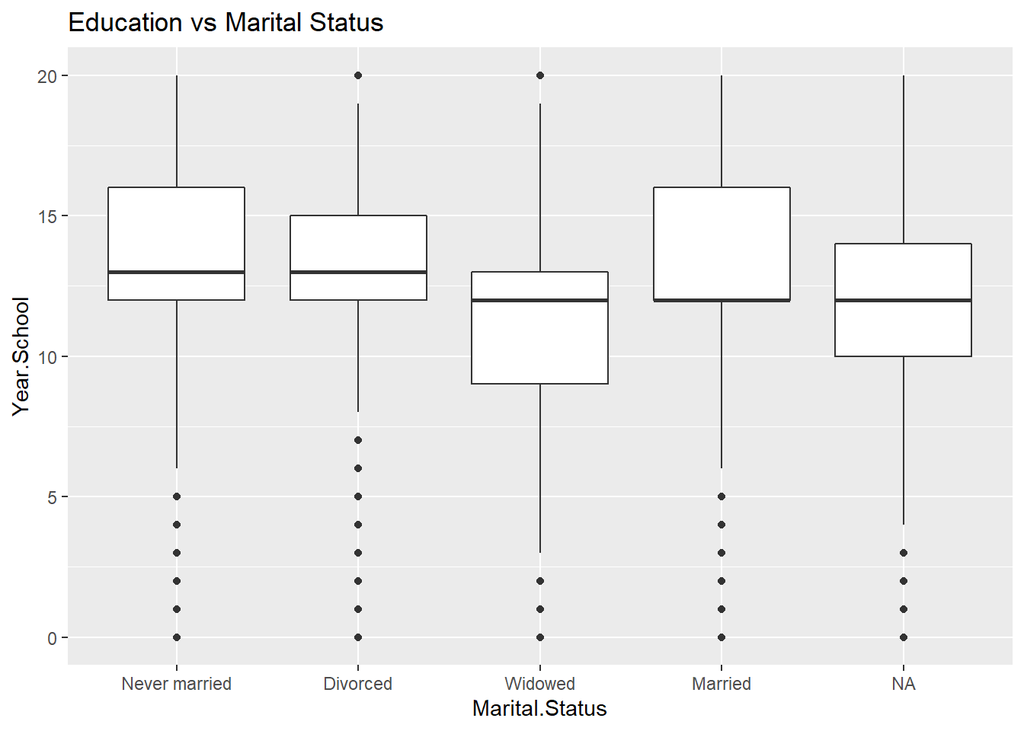

```r
ggplot(marriedData, aes(x=Marital.Status, y=Year.School)) + geom_boxplot() + ggtitle("Education vs Marital Status")
```

The graph above shows the relatively drastic difference when looking at widowed respondents versus the other three demographics.

## Question 6: Effect of Children

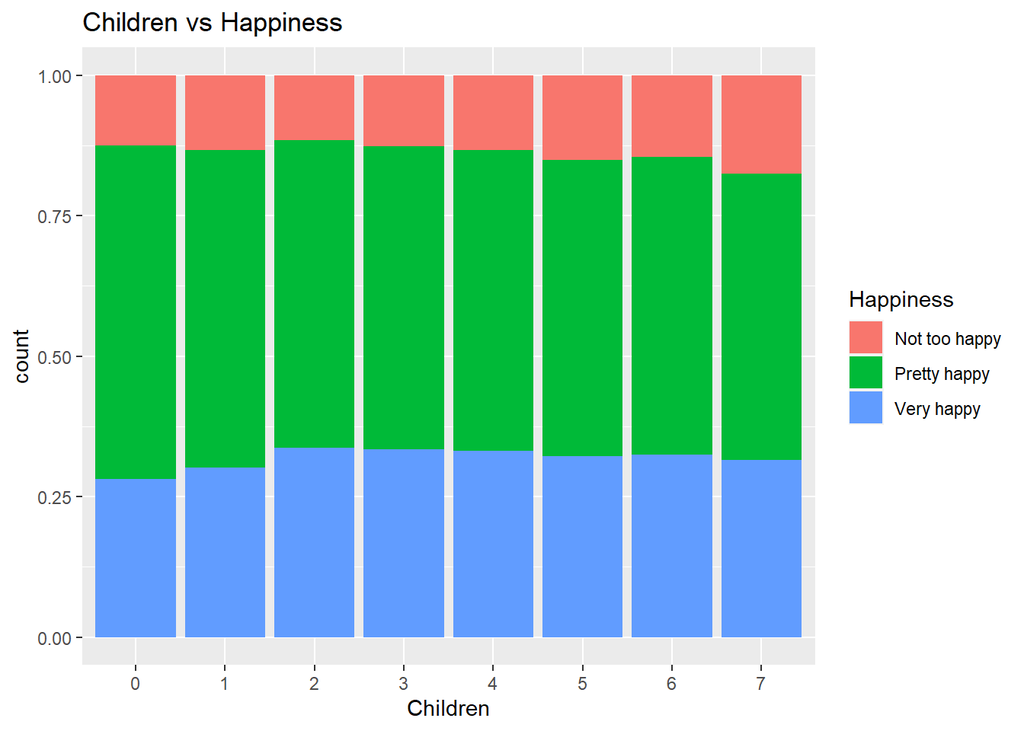

```r
childrenHappiness <- dat %>% select(Happiness, Children) %>%
  drop_na %>%
  filter(Happiness != "Don't know" & Happiness != "No answer" &
           Happiness != 'Not applicable') %>%
  mutate(Children = factor(Children, levels = c(0, 1, 2, 3, 4, 5, 6, 7))) %>%
  arrange(Children)
ggplot(childrenHappiness, aes(x=Children, fill=Happiness)) + geom_bar(position = 'fill') + ggtitle("Children vs Happiness")
```

First step I took was looking at the number of children vs Happiness but that turned up nothing remarkable like I was expecting. My hypothesis was that their would be a number that had more happiness to be considered the “ideal” number of children but that was not the case. It is all fairly even. So next I looked at the religoin of the respondent versus children to see if there was trend in the amount of kids per religion.

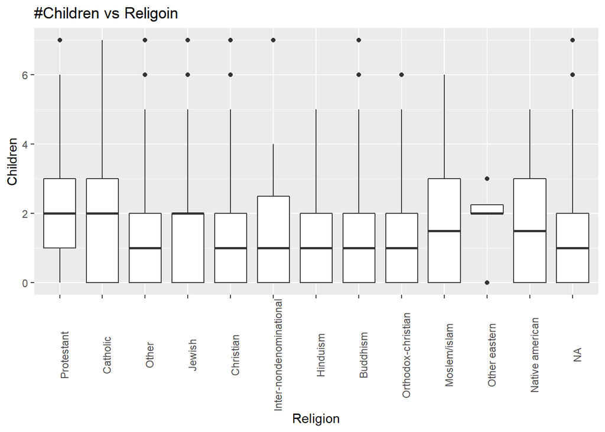

```r
temp <- dat %>% select(Religion) %>% unique
religionLevels <- c('Protestant', 'Catholic', 'Other', 'Jewish', 'Christian', 'Inter-nondenominational', 'Hinduism', 'Buddhism', 'Orthodox-christian', 'Moslem/islam', 'Other eastern', 'Native american')
childrenHappiness <- dat %>% select(Religion, Children) %>%
  drop_na %>%
  filter(Religion != "Don't know" & Religion != "No answer" &
           Religion != 'Not applicable') %>%
  mutate(Religion = factor(Religion, levels = religionLevels)) %>%
  arrange(Religion)
ggplot(childrenHappiness, aes(x=Religion, y=Children)) + geom_boxplot() + theme(axis.text.x=element_text(angle=90))+ ggtitle("#Children vs Religoin")
```

The above graph shows that there is some differences with Catholics, Protestants, and Jewish respondents had the highest average and the middle chunk of religions, Christian, Inter-nondenominational, Hinduism, Buddhism and Orthodox-christian all were relatively the same. Protestant was the only, large religion, that had the range from the first quartile to third quartile not resting on 0 for number of children.